# *Reproducible Research for FIFA World Cup Analysis in R*

*Vadym Dudarenko*  
*Ivan Grakhovski*  
*Ismayil Ismayilov*

# Project Description

- This project is aimed at using machine learning to predict the outcomes of football matches. More specifically, it uses the Support Vector Machines (SVM) model to determine the winning team. The project has been jointly undertaken by Ismayil, Vadym, and Ivan.
- This project was undertaken as a part of an academic task that required the translation of statistical analysis from one programming language to another. The original study, conducted in Python, was translated into R, and the analysis was reproduced. The process offered us an opportunity to understand the nuances of different programming languages and how the same task can be executed differently in each.

## Data Acquisition and Preparation

- The data for this project comes from two CSV files: matches_1930_2022.csv and world_cup.csv. The first file contains data on soccer matches from 1930 through 2022, while the second one provides information on World Cup matches.
- In the data preparation phase, unneeded columns from the matches dataset are dropped, focusing on essential match details such as home team, away team, and scores. Teams’ names are replaced with appropriate names where necessary. A numeric index is assigned to each unique team name for more manageable data processing.
- Next, the championships won by each team are counted, and new columns, Home_Team_Champions and Away_Team_Champions, are added to the matches dataset, indicating how many times the home and away teams have won championships, respectively.
- The winning team for each match is calculated and added to the dataset as the column Winner.

## Data Analysis

- After data preparation, the dataset is visualized to see the distribution of World Cup championships by country. Next, teams’ names are replaced with their corresponding numeric indices. Finally, missing values are replaced with appropriate values.
- The dataset is then split into training and test sets, with 70% of the data used for training the SVM model and 30% used for testing it.

## Modeling

- A Support Vector Machines (SVM) model is used to predict match outcomes. The model is trained on the Winner attribute with other columns as features.

## Model Evaluation

```r
library(e1071)
library(caret)
library(dplyr)
library(tidyverse)
```

```r
library(ggplot2)
```

*Loading data*

```r
matches_1930_2022 <- read.csv("matches_1930_2022.csv")
```

```r
world_cup <- read.csv("C:/Users/Vadym/Desktop/Reproducible/project/world_cup.csv")
```

*Data Preparation*  
First we remove unnecessary columns from the matches data, then activate function replace_teams.

```r
matches <- matches_1930_2022[, -c(9, 10, 11, 12, 14,15,18,19,20,23,24,25,26,27,28,29,30,31,32,33,34,35,36,37,38,39,40,41,42,43,44,45)]
```

```r
replace_teams <- function(matches) {
  matches$home_team[matches$home_team %in% c("German DR", "Germany FR")] <- "Germany"
  matches$home_team[matches$home_team == "Soviet Union"] <- "Russia"

  matches$away_team[matches$away_team %in% c("German DR", "Germany FR")] <- "Germany"
  matches$away_team[matches$away_team == "Soviet Union"] <- "Russia"

  return(matches)
}

matches <- replace_teams(matches)
```

*Create a dictionary of football team*  
We create an empty list to store tem names, then initialize an index for team names. After that we print the dictionary of football team names.

```r
team_name <- list()
index <- 0

for (i in 1:nrow(matches)) {
  name <- matches[i, "home_team"]
  if (!(name %in% names(team_name))) {
    team_name[[name]] <- index
    index <- index + 1
  }

  name <- matches[i, "away_team"]
  if (!(name %in% names(team_name))) {
    team_name[[name]] <- index
    index <- index + 1
  }
}

team_name
```

```
## $Argentina
## [1] 0
##
## $France
## [1] 1
##
## $Croatia
## [1] 2
##
## $Morocco
## [1] 3
##
## $Portugal
## [1] 4
##
## $England
## [1] 5
##
## $Brazil
## [1] 6
##
## $Netherlands
## [1] 7
##
## $Spain
## [1] 8
##
## $Switzerland
## [1] 9
##
## $Japan
## [1] 10
##
## $`Korea Republic`
## [1] 11
##
## $Poland
## [1] 12
##
## $Senegal
```

[output cut: 199 more lines]

```
##
## $Haiti
## [1] 80
##
## $Zaire
## [1] 81
##
## $Israel
## [1] 82
##
## $Cuba
## [1] 83
##
## $`Dutch East Indies`
## [1] 84
```

*Print the number of World Cup championships by country*

```r
championships <- table(ifelse(world_cup$Champion == "West Germany", "Germany", world_cup$Champion))
championships
```

```
##
## Argentina    Brazil   England    France   Germany     Italy     Spain   Uruguay
##         3         5         1         2         4         4         1         2
```

*Create a countplot*

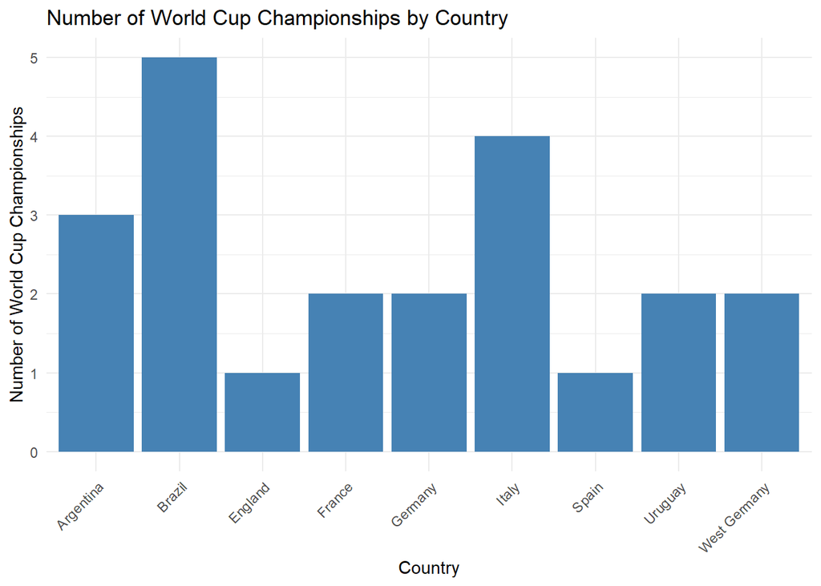

```r
ggplot(world_cup, aes(x = Champion)) +
  geom_bar(fill = "steelblue") +
  labs(x = "Country", y = "Number of World Cup Championships") +
  ggtitle("Number of World Cup Championships by Country") +
  theme_minimal() +
  theme(axis.text.x = element_text(angle = 45, hjust = 1))
```

*Set the initual values of “Home_Team_Champions” and “Away_Team_Champions” columns in the “matches” dataset to 0*

```r
matches$Home_Team_Champions <- 0
matches$Away_Team_Champions <- 0


if (!is.null(championships[matches$home_team])) {
  matches$Home_Team_Champions <- championships[matches$home_team]
}

if (!is.null(championships[matches$away_team])) {
  matches$Away_Team_Champions <- championships[matches$away_team]
}
```

*Create a new column named “Winner” in the “matches” dataset and initialize all values as “-”, then define function “calculate winner” to determine the winner based on goal scores. After that update “matches” dataset with winnerinformation.*

```r
matches$Winner <- "-"

calculate_winner <- function(matches) {
  home_team_goal <- as.integer(matches$home_score)
  away_team_goal <- as.integer(matches$away_score)
  matches$Winner <- ifelse(home_team_goal == away_team_goal, 0, ifelse(home_team_goal > away_team_goal, 1, 2))

  return(matches)
}

matches <- calculate_winner(matches)

table(matches$Winner)
```

```
##
##   0   1   2
## 214 532 218
```

*Define function “replace_team_name” to replace team names in “matches” dataset. Update “matches” dataset with replaced team names”.*

```r
replace_team_name <- function(matches) {
  matches$home_team <- team_name[matches$home_team]
  matches$away_team <- team_name[matches$away_team]
  return(matches)
}

matches <- replace_team_name(matches)
```

*Remove unnecessary columns from “matches” dataset. Replace NA values with 0.*

```r
matches <- matches[, -c(5, 8, 9, 10, 11, 12, 13)]
matches <- matches[, -c(3,4,5,6)]


matches$Away_Team_Champions <- ifelse(is.na(matches$Away_Team_Champions), 0, matches$Away_Team_Champions)
matches$Home_Team_Champions <- ifelse(is.na(matches$Home_Team_Champions), 0, matches$Home_Team_Champions)
```

*Unlist the dataset*  
Then convert data types and unlist columns in “matches” dataset.

```r
class(matches)
```

```
## [1] "data.frame"
```

```r
matches$Home_Team_Champions<-as.numeric(matches$Home_Team_Champions)
matches$Away_Team_Champions<-as.numeric(matches$Away_Team_Champions)
matches$away_team <- unlist(matches$away_team)
matches$home_team <- unlist(matches$home_team)

#mean_value <- mean(matches$home_xg, na.rm = TRUE)
#matches$home_xg <- ifelse(is.na(matches$home_xg), mean_value, matches$home_xg)
#mean_value1 <- mean(matches$away_xg, na.rm = TRUE)
#matches$away_xg <- ifelse(is.na(matches$away_xg), mean_value1, matches$away_xg)
```

*Create indices for the training and test sets*

```r
# Create indices for the training and test sets
sample <- sample(c(TRUE, FALSE), nrow(matches), replace=TRUE, prob=c(0.7,0.3))
train <- matches[sample, ]
test <- matches[!sample, ]
```

*Build an SVM model for classification using the training data*

```r
model <- svm(Winner ~.,
                 data = train,
                 type = 'C-classification',
                 kernel = 'linear',
                scale = FALSE)
model
```

```
##
## Call:
## svm(formula = Winner ~ ., data = train, type = "C-classification",
##     kernel = "linear", scale = FALSE)
##
##
## Parameters:
##    SVM-Type:  C-classification
##  SVM-Kernel:  linear
##        cost:  1
##
## Number of Support Vectors:  576
```

*Make predictions in the test data using the trained data. Print the predicted values*

```r
pred_test <- predict(model,newdata = test)
pred_test
```

```
##   3   4   7   8  14  17  18  19  20  25  26  27  29  33  34  36  37  39  42  43
##   1   1   1   1   1   1   1   1   1   1   1   1   1   1   1   1   1   1   1   1
##  44  48  51  58  62  64  65  71  75  76  77  86  87  88  91  92  96  97  98 101
##   1   1   1   1   1   1   1   1   1   1   1   1   1   1   1   1   1   1   1   1
## 103 107 112 115 117 119 120 122 124 126 129 135 136 138 141 142 144 145 146 150
##   1   1   1   1   1   1   1   1   1   1   1   1   1   1   1   1   1   1   1   1
## 158 163 164 166 167 174 177 180 183 188 191 197 200 202 203 205 207 218 226 227
##   1   1   1   1   1   1   1   1   1   1   1   1   1   1   1   1   1   1   1   1
## 229 231 233 234 236 237 242 243 244 250 255 264 265 266 272 275 281 282 283 284
##   1   1   1   1   1   1   1   1   1   1   1   1   1   1   1   1   1   1   1   1
## 289 292 296 297 299 303 304 306 309 311 319 324 325 330 335 338 341 342 347 348
##   1   1   1   1   1   1   1   1   1   1   1   1   1   1   1   1   1   1   1   1
## 350 353 362 369 370 372 375 380 381 383 384 385 388 389 393 394 400 402 404 407
##   1   1   1   1   1   1   1   1   1   1   1   1   1   1   1   1   1   1   1   1
## 409 411 413 414 416 417 423 425 427 433 440 441 455 462 463 465 477 478 480 481
```

[output cut: 18 more lines]

*Make predictions on the training data using the train model and store the results, then calculate the accuracy of the model on the training data by comparing the predictions with the actual values.*

```r
pred_train1 <- predict(model, train)
mean(pred_train1 == train$Winner)
```

```
## [1] 0.553681
```

```r
pred_test <- predict(model, test)
mean(pred_test == test$Winner)
```

```
## [1] 0.5480769
```

*Create a data frame named results containing the actual and predicted values from the test data.*

```r
results <- data.frame(Actual = test$Winner, Predicted = pred_test)
```

*Use the caret package’s confusionMatrix() function to calculate evaluation metrics.*

```r
# Use the caret package's confusionMatrix() function to calculate evaluation metrics
cm <- confusionMatrix(data = factor(results$Predicted),
                      reference = factor(results$Actual))
```

*Print the classification report, which includes evaluation metrics calculated using the confusion matrix.*

```r
print(cm)
```

```
## Confusion Matrix and Statistics
##
##           Reference
## Prediction   0   1   2
##          0   0   0   0
##          1  75 171  66
##          2   0   0   0
##
## Overall Statistics
##
##                Accuracy : 0.5481
##                  95% CI : (0.491, 0.6042)
##     No Information Rate : 0.5481
##     P-Value [Acc > NIR] : 0.5234
##
##                   Kappa : 0
##
##  Mcnemar's Test P-Value : NA
##
## Statistics by Class:
##
##                      Class: 0 Class: 1 Class: 2
## Sensitivity            0.0000   1.0000   0.0000
## Specificity            1.0000   0.0000   1.0000
## Pos Pred Value            NaN   0.5481      NaN
## Neg Pred Value         0.7596      NaN   0.7885
## Prevalence             0.2404   0.5481   0.2115
## Detection Rate         0.0000   0.5481   0.0000
## Detection Prevalence   0.0000   1.0000   0.0000
## Balanced Accuracy      0.5000   0.5000   0.5000
```